# Project: Identify Customer Segments

### Discussion 3.1: Apply Clustering to General Population

Also, i used a subset of the data (200,000 records, about 25% of the total data) to find scores to draw the elbow chart.

### Step 3.2: Apply All Steps to the Customer Data

Now that you have clusters and cluster centers for the general population, it's time to see how the customer data maps on to those clusters. Take care to not confuse this for re-fitting all of the models to the customer data. Instead, you're going to use the fits from the general population to clean, transform, and cluster the customer data. In the last step of the project, you will interpret how the general population fits apply to the customer data.

- Don't forget when loading in the customers data, that it is semicolon (`;`) delimited.
- Apply the same feature wrangling, selection, and engineering steps to the customer demographics using the `clean_data()` function you created earlier. (You can assume that the customer demographics data has similar meaning behind missing data patterns as the general demographics data.)
- Use the sklearn objects from the general demographics data, and apply their transformations to the customers data. That is, you should not be using a `.fit()` or `.fit_transform()` method to re-fit the old objects, nor should you be creating new sklearn objects! Carry the data through the feature scaling, PCA, and clustering steps, obtaining cluster assignments for all of the data in the customer demographics data.

```python
# Load in the customer demographics data.
customers = pd.read_csv("./Udacity_CUSTOMERS_Subset.csv", sep = ";")
customers.columns = feat_info["attribute_in_English"]
```

```python
# Apply preprocessing, feature transformation, and clustering from the general
# demographics onto the customer data, obtaining cluster predictions for the
# customer demographics data.

# Cleaning_data
customers = clean_data(customers, feat_info, missing_or_unknown_lst)
print(customers.shape)

# Median imputation
customers_imputed = model_imp.transform(customers)

# Standard Scaling
X_cust = model_scaler.transform(customers_imputed)

# pca
X_cust_pca = model_pca.transform(X_cust)

# Kmeans predict
predictions_cust = model_kmeans.predict(X_cust_pca)
```

```
(191652, 200)
```

### Step 3.3: Compare Customer Data to Demographics Data

At this point, you have clustered data based on demographics of the general population of Germany, and seen how the customer data for a mail-order sales company maps onto those demographic clusters. In this final substep, you will compare the two cluster distributions to see where the strongest customer base for the company is.

Consider the proportion of persons in each cluster for the general population, and the proportions for the customers. If we think the company's customer base to be universal, then the cluster assignment proportions should be fairly similar between the two. If there are only particular segments of the population that are interested in the company's products, then we should see a mismatch from one to the other. If there is a higher proportion of persons in a cluster for the customer data compared to the general population (e.g. 5% of persons are assigned to a cluster for the general population, but 15% of the customer data is closest to that cluster's centroid) then that suggests the people in that cluster to be a target audience for the company. On the other hand, the proportion of the data in a cluster being larger in the general population than the customer data (e.g. only 2% of customers closest to a population centroid that captures 6% of the data) suggests that group of persons to be outside of the target demographics.

Take a look at the following points in this step:

- Compute the proportion of data points in each cluster for the general population and the customer data. Visualizations will be useful here: both for the individual dataset proportions, but also to visualize the ratios in cluster representation between groups. Seaborn's [`countplot()`](https://seaborn.pydata.org/generated/seaborn.countplot.html) or [`barplot()`](https://seaborn.pydata.org/generated/seaborn.barplot.html) function could be handy.
  - Recall the analysis you performed in step 1.1.3 of the project, where you separated out certain data points from the dataset if they had more than a specified threshold of missing values. If you found that this group was qualitatively different from the main bulk of the data, you should treat this as an additional data cluster in this analysis. Make sure that you account for the number of data points in this subset, for both the general population and customer datasets, when making your computations!
- Which cluster or clusters are overrepresented in the customer dataset compared to the general population? Select at least one such cluster and infer what kind of people might be represented by that cluster. Use the principal component interpretations from step 2.3 or look at additional components to help you make this inference. Alternatively, you can use the `.inverse_transform()` method of the PCA and StandardScaler objects to transform centroids back to the original data space and interpret the retrieved values directly.
- Perform a similar investigation for the underrepresented clusters. Which cluster or clusters are underrepresented in the customer dataset compared to the general population, and what kinds of people are typified by these clusters?

```python
# Compare the proportion of data in each cluster for the customer data to the
# proportion of data in each cluster for the general population.
df_pop_pred = pd.DataFrame(predictions, columns = ["prediction"])
df_cust_pred = pd.DataFrame(predictions_cust, columns = ["prediction"])
```

```python
df_pop_pred_vc = df_pop_pred["prediction"].value_counts(normalize = True)
df_cust_pred_vc = df_cust_pred["prediction"].value_counts(normalize = True)
```

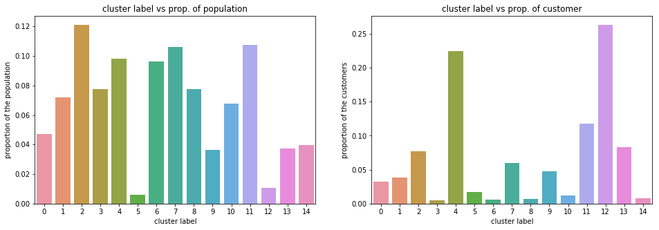

```python
fig, (ax1, ax2) = plt.subplots(1,2,figsize = (16,5))
sns.barplot(x = df_pop_pred_vc.index, y = df_pop_pred_vc, ax = ax1)
ax1.set_title("cluster label vs prop. of population")
ax1.set_xlabel("cluster label")
ax1.set_ylabel("proportion of the population")
sns.barplot(x = df_cust_pred_vc.index, y = df_cust_pred_vc, ax = ax2)
ax2.set_title("cluster label vs prop. of customer")
ax2.set_xlabel("cluster label")
ax2.set_ylabel("proportion of the customers")
plt.show()
```

```python
# What kinds of people are part of a cluster that is overrepresented in the
# customer data compared to the general population?

# Six clusters have overrepresentation in the customer data compared to the general population - 11,5,9,13,4,12. 4 and 12 have
# the most over representation. The difference in proportion being 12.7% and 25.3% respectively. So lets take cluster no. 4
# for further scrunity.

cluster_centre = model_kmeans.cluster_centers_[4]
inverse_pca =  pca.inverse_transform(cluster_centre)
inverse_scaler = scaler.inverse_transform(inverse_pca)
df_temp = pd.DataFrame(inverse_scaler)
df_temp.index = azdias_less_NaNs.columns

cluster_feature_info = df_temp.sort_values(by = 0, axis = 0, ascending = False)

print(cluster_feature_info)
```

```
                                              0
First-year-building-mentioned       1992.950941
Year-of-birth                       1960.140587
Num-cars-PLZ8-region                 693.735159
Birthdate-of-head-of-household        14.639075
Length-of-residence                    8.576542
persnlity-typo-sensual-minded          5.243004
size-community                         5.203859
persnlity-typo-event-oriented          5.179146
Distance-to-city-center                4.783654
persnlity-typo-dreamful                4.698533
persnlity-typo-dominant-minded         4.669499
Fin-typo-low-financial-interest        4.549752
persnlity-typo-critical-minded         4.358779
Distance-nearest-urban-center          4.221313
Movement-patterns                      4.213410
persnlity-typo-combative attitude      4.211688
Fin-typo-be-prepared                   4.204131
Num-buildings-within-microcell         4.148443
Likelihood-of-children-household       4.087352
persnlity-typo-socially-minded         4.059557
ratio-res-to-comm-activity             4.010622
Num-buildings-within-PLZ8              3.905519
Density-households-per-sqkm            3.830293
Neighborhood-typo                      3.699505
return-type                            3.689851
Num-households-within-PLZ8             3.672878
youth-dominating-movement_decade       3.550701
persnlity-typo-cultural-minded         3.547916
Welth-life-stage-intl-code_LS          3.493002
persnlity-typo-family-minded           3.474677
...                                         ...
Welth-life-stage-detail-scale_7C       0.004762
Welth-life-stage-detail-scale_9A       0.003671
Welth-life-stage-detail-scale_8D       0.003318
Family-type-fine-scale_7.0             0.002653
Welth-life-stage-detail-scale_7D       0.002484
Social-status-fine-scale_8.0           0.001913
Welth-life-stage-detail-scale_9B       0.001646
Welth-life-stage-detail-scale_1E       0.001597
```

[output cut: 9 more lines]

```
Social-status-fine-scale_nan          -0.000096
Social-status-rough-scale_nan         -0.000096
Preferred-info-buying-channels_nan    -0.000096
Social-status-rough-scale_4.0         -0.000720
Welth-life-stage-detail-scale_1B      -0.000882
Welth-life-stage-detail-scale_9E      -0.001265
Family-type-fine-scale_6.0            -0.001839
Welth-life-stage-detail-scale_1A      -0.002036
Social-status-fine-scale_9.0          -0.002632
Num-6-10-family-houses-microcell      -0.007923
Social-status-fine-scale_5.0          -0.013508
Energy-consumption-typology_5         -0.014002
financial-type-description_1          -0.016368

[200 rows x 1 columns]
```

```python
# What kinds of people are part of a cluster that is underrepresented in the
# customer data compared to the general population?

# Cluster 6 is the most underrepresented

cluster_centre = model_kmeans.cluster_centers_[6]
inverse_pca =  pca.inverse_transform(cluster_centre)
inverse_scaler = scaler.inverse_transform(inverse_pca)
df_temp = pd.DataFrame(inverse_scaler)
df_temp.index = azdias_less_NaNs.columns

cluster_feature_info = df_temp.sort_values(by = 0, axis = 0, ascending = False)

print(cluster_feature_info)
```

```
                                              0
First-year-building-mentioned       1992.372137
Year-of-birth                       1977.422701
Num-cars-PLZ8-region                 536.091211
Birthdate-of-head-of-household        17.219225
Num-households-in-building            14.255473
Length-of-residence                    7.107820
size-community                         6.817341
persnlity-typo-dominant-minded         6.302270
persnlity-typo-combative attitude      6.205520
persnlity-typo-rational                6.173255
persnlity-typo-dutiful                 6.046158
persnlity-typo-tradional-minded        5.790284
youth-dominating-movement_decade       5.703538
Estimated-household-net-income         5.627636
persnlity-typo-critical-minded         5.485875
persnlity-typo-religious               5.122328
Density-households-per-sqkm            5.042358
Neighborhood-typo                      4.882565
persnlity-typo-materialistic           4.790046
Fin-typo-money-saver                   4.385682
Welth-life-stage-intl-code_ES          4.352806
Fin-typo-investor                      4.295015
Fin-typo-home ownership                4.265682
persnlity-typo-event-oriented          4.239807
persnlity-typo-cultural-minded         4.056064
Likelihood-of-children-household       3.986653
Num-households-within-PLZ8             3.769807
persnlity-typo-family-minded           3.762805
Fin-typo-inconspicuous                 3.755394
Share-of-unemploy-relative-county      3.640038
...                                         ...
Welth-life-stage-detail-scale_6F       0.004669
Welth-life-stage-detail-scale_1A       0.004463
Welth-life-stage-detail-scale_5E       0.004303
Welth-life-stage-detail-scale_5F       0.003875
Welth-life-stage-detail-scale_2D       0.003845
Welth-life-stage-detail-scale_9E       0.003090
Welth-life-stage-detail-scale_2A       0.003049
Welth-life-stage-detail-scale_4E       0.003010
```

[output cut: 9 more lines]

```
Welth-life-stage-detail-scale_1B       0.000287
Welth-life-stage-rough-scale_nan       0.000124
Welth-life-stage-detail-scale_nan      0.000124
Social-status-fine-scale_8.0           0.000089
Preferred-info-buying-channels_nan    -0.000127
Vacation-habits_nan                   -0.000127
Social-status-rough-scale_nan         -0.000127
Social-status-fine-scale_nan          -0.000127
Welth-life-stage-detail-scale_2C      -0.000715
Welth-life-stage-detail-scale_3A      -0.000952
Welth-life-stage-detail-scale_3B      -0.001164
financial-type-description_5          -0.006870
Social-status-fine-scale_5.0          -0.008415

[200 rows x 1 columns]
```

### Discussion 3.3: Compare Customer Data to Demographics Data

The company seems to be very popular or extensively targets customers Year-of-birth is around 1960 and live in houses that were first reported around 1992 and they would living in a relatively wealthy neighborhood as evidenced by average of 694 cars in the PLZ8 region. As well as the households targeted by the company mostly has a head who was born between 1960 and 1964. They would have lived in the same house for approximately 8.5 years and they would be located around 5 kilometers from the city centre. Moreover, they are mostly critical minded and live around 4 kilometers from the nearest urban centre and they would be very high income earners coming from high purchasing power regions. Seems like the company is very popular among wealthy but relatiely elderly people.

The company seems to be unpopular or hasn't yet fully exploited the following segment of people. Their house would have been first mentioned in year 1992 and they would have been born around 1977. The head of the household would have been born between 1975-1979 and they would also be living in the same household for around 7 years. These customers would have following personality traits - dominant minded, combative attitude, rational, dutiful and traditional minded. Also, they would be in lower income bracket and located in the region with average purchasing power. Seems like the company is unpopular among low income middle aged, conservative people.

> Congratulations on making it this far in the project! Before you finish, make sure to check through the entire notebook from top to bottom to make sure that your analysis follows a logical flow and all of your findings are documented in **Discussion** cells. Once you've checked over all of your work, you should export the notebook as an HTML document to submit for evaluation. You can do this from the menu, navigating to **File -> Download as -> HTML (.html)**. You will submit both that document and this notebook for your project submission.